# Mapping Crimean-Congo Haemorrhagic Fever in Africa with BART

# Getting Started

So you’re interested in using to do species distribution modeling with Bayesian additive regression trees! That’s great. BARTs are a powerful way to do machine learning and, while not a new method per se, they are very new for SDMs.

In this advanced tutorial, I’m going to assume that you’ve seen the main paper and the `embarcadero` package vignette, which goes over basic functions and some of the internal structure of BART models. This tutorial, and the associated repo (`cjcarlson/pier39`), are intended for advanced users interested in seeing what a professional workflow might look like for an applied use.

```r
library(embarcadero)
set.seed(12345)
```

Our goal here is to do a few things:

1. Build a species distribution model for *Hyalomma truncatum*, a tick we think might be a vector of Crimean-Congo haemorrhagic fever (CCHF) in Africa.
2. To build a transmission risk map, again using species distribution modeling/ecological niche modeling, for CCHF in Africa.
3. To see if we learn anything from that model about CCHF we didn’t know before.
4. To see some of the advanced visualization and workflow tricks in the `embarcadero` package!

# Mapping Hyalomma

We’re going to make a suitability layer for *Hyalomma truncatum*, a possible CCHF vector. The tick occurrence data, which is a set of presence points, comes from Cumming et al. (1998) *Bulletin of Entomological Research*, one of the most detailed datasets in the world on parasite distributions. We’re going to build a species distribution model using those points, some climate data, and a few other convenient layers that might be relevant.

## Data entry

Let’s start by loading in the climate data. We’ll use three main sources:

1. WorldClim v1.4 (Hijmans et al. 2005), a harmonized dataset of bioclimatic variables mostly used for species distribution modeling
2. Two layers describing long-term averages of the normalized difference vegetation index (NDVI), which captures the greenness of a landscape (taken from previous use in Carlson et al. 2018). This can be an important variable for measuring invertebrate distributions, for example, or partitioning landscapes into different biomes.
3. A layer produced by the NASA SEDAC center describing the percent cropland by grid cell. If we think ruminants are spreading CCHF, this might matter! (https://sedac.ciesin.columbia.edu/data/set/aglands-croplands-2000)

Based on some expert opinion, I picked a handful of variables I thought might work well (and it’s already reduced down to minimize redunandancy):

- BIO1: Mean annual temperature
- BIO2: Mean diurnal range
- BIO5: Max temperature of warmest month
- BIO6: Min temperature of coldest month
- BIO12: Mean annual precipitation
- BIO13: Precipitation of wettest month
- BIO14: Precipitation of driest month
- BIO15: Precipitation seasonality
- Mean NDVI (normalized difference vegetation index)
- NDVI amplitude
- Percent cropland by pixel

Let’s read in the covariates.

```r
load(file = "~/Github/pier39/covsraw.rda"); covs <- covsraw
class(covs)
```

```
#> [1] "RasterStack"
#> attr(,"package")
#> [1] "raster"
```

```r
covs@crs <- crs('+proj=longlat +ellps=WGS84 +datum=WGS84 +no_defs +towgs84=0,0,0')
```

Next, let’s load in our tick occurrence dataset, which is a set of longitude/latitude coordinates.

```r
load(file = "~/Github/pier39/ticks.rda")
head(ticks)
```

|  | X | ScientificName | Longitude.X | Latitude.Y |
| --- | --- | --- | --- | --- |
| 1 | 16471 | Hyalomma truncatum | 16 | -8.2 |
| 2 | 16472 | Hyalomma truncatum | 14 | -12.5 |
| 3 | 16473 | Hyalomma truncatum | 12 | -5.5 |
| 4 | 16474 | Hyalomma truncatum | 15 | -16.5 |
| 5 | 16475 | Hyalomma truncatum | 14 | -13.6 |
| 6 | 16476 | Hyalomma truncatum | 15 | -12.4 |

```r
nrow(ticks)
```

```
#> [1] 1794
```

Presence points are usually a little aggregated in space, so as a normal data cleaning practice, I like to thin my occurrence data to one point per raster grid cell.

```r
# Make a spatial point data frame
mod <- SpatialPointsDataFrame(ticks[,3:4],data.frame(ticks[,1]))
names(mod@data) <- 'Presence'
nrow(mod)
```

```
#> [1] 1794
```

```r
# Rasterizing and converting back to points makes one unique point per grid cell
tmp=rasterize(mod, covs[[1]], field="Presence", fun="min")
pts.sp1=rasterToPoints(tmp, fun=function(x){x>0})
nrow(pts.sp1)
```

```
#> [1] 1716
```

```r
# Extract the climate data at each point
pres.cov <- raster::extract(covs, pts.sp1[,1:2])
head(pres.cov)
```

```
#>      bio1  bio12  bio13  bio14 bio15 bio2 bio5 bio6  crop ndvi.amp
#> [1,]   29 0.0064 0.0090 0.0042  0.15   23   47  8.0 0.000    0.050
#> [2,]   30 0.0061 0.0092 0.0037  0.17   23   48  8.7 0.000    0.056
#> [3,]   32 0.0090 0.0117 0.0064  0.16   22   48 11.3 0.000    0.105
#> [4,]   32 0.0085 0.0145 0.0036  0.38   21   47 14.7 0.031    0.032
#> [5,]   31 0.0081 0.0154 0.0028  0.45   21   46 12.4 0.011    0.014
#> [6,]   32 0.0087 0.0148 0.0037  0.38   21   47 14.9 0.044    0.151
#>      ndvi.mean
#> [1,]    -0.015
#> [2,]     0.016
#> [3,]     0.095
#> [4,]     0.127
#> [5,]     0.122
#> [6,]    -0.039
```

Next, let’s generate an equal number of pseudoabsences around Africa to the number of presences we have. BARTs are like BRTs in that they are sensitive to assumed prevalence; anecdotally, I strongly suggest using an equal number of presences and absences in your training data. You can experiment with the demo data by changing “nrow(ticks)” to “5000” below if you want to see some weirder model behavior.

```r
#Generate the data
absence <- randomPoints(covs,nrow(ticks))
abs.cov <- raster::extract(covs, absence)

#Code the response
pres.cov <- data.frame(pres.cov); pres.cov$tick <- 1
abs.cov <- data.frame(abs.cov); abs.cov$tick <- 0

# And one to bind them
all.cov <- rbind(pres.cov, abs.cov)
head(all.cov)
```

|  | bio1 | bio12 | bio13 | bio14 | bio15 | bio2 | bio5 | bio6 | crop | ndvi.amp | ndvi.mean | tick |
| --- | --- | --- | --- | --- | --- | --- | --- | --- | --- | --- | --- | --- |
| 1 | 29 | 0.0064 | 0.0090 | 0.0042 | 0.15 | 23 | 47 | 8.0 | 0.000 | 0.050 | -0.015 | 1 |
| 2 | 30 | 0.0061 | 0.0092 | 0.0037 | 0.17 | 23 | 48 | 8.7 | 0.000 | 0.056 | 0.016 | 1 |
| 3 | 32 | 0.0090 | 0.0117 | 0.0064 | 0.16 | 22 | 48 | 11.3 | 0.000 | 0.105 | 0.095 | 1 |
| 4 | 32 | 0.0085 | 0.0145 | 0.0036 | 0.38 | 21 | 47 | 14.7 | 0.031 | 0.032 | 0.127 | 1 |
| 5 | 31 | 0.0081 | 0.0154 | 0.0028 | 0.45 | 21 | 46 | 12.4 | 0.011 | 0.014 | 0.122 | 1 |
| 6 | 32 | 0.0087 | 0.0148 | 0.0037 | 0.38 | 21 | 47 | 14.9 | 0.044 | 0.151 | -0.039 | 1 |

```r
# Let's just clean it up a little bit - remove any missing data
all.cov <- all.cov[complete.cases(all.cov),]
```

Now we have a dataset ready to do some modeling!

## Running models with dbarts

We could try something really simple on defaults, right out the gate. The function in can just be run on defaults:

```r
xvars <- names(all.cov)[!(names(all.cov)=='tick')]
xvars
```

```
#>  [1] "bio1"      "bio12"     "bio13"     "bio14"     "bio15"
#>  [6] "bio2"      "bio5"      "bio6"      "crop"      "ndvi.amp"
#> [11] "ndvi.mean"
```

```r
first.model <- bart(all.cov[,xvars], all.cov[,'tick'], keeptrees=TRUE)
```

```
#>
#> Running BART with binary y
#>
#> number of trees: 200
#> number of chains: 1, number of threads 1
#> Prior:
#>  k: 2.000000
#>  power and base for tree prior: 2.000000 0.950000
#>  use quantiles for rule cut points: false
#> data:
#>  number of training observations: 3478
#>  number of test observations: 0
#>  number of explanatory variables: 11
#>
#> Cutoff rules c in x<=c vs x>c
#> Number of cutoffs: (var: number of possible c):
#> (1: 100) (2: 100) (3: 100) (4: 100) (5: 100)
#> (6: 100) (7: 100) (8: 100) (9: 100) (10: 100)
#> (11: 100)
#>
#> offsets:
#>  reg : 0.00 0.00 0.00 0.00 0.00
#> Running mcmc loop:
#> iteration: 100 (of 1000)
#> iteration: 200 (of 1000)
#> iteration: 300 (of 1000)
#> iteration: 400 (of 1000)
#> iteration: 500 (of 1000)
#> iteration: 600 (of 1000)
#> iteration: 700 (of 1000)
#> iteration: 800 (of 1000)
#> iteration: 900 (of 1000)
#> iteration: 1000 (of 1000)
#> total seconds in loop: 11.929348
#>
#> Tree sizes, last iteration:
#> [1] 2 2 2 2 3 3 2 3 2 2 2 2 3 3 4 3 3 2
#> 3 3 4 1 4 2 2 3 2 4 3 5 5 2 3 2 3 2 3 1
#> 3 2 1 3 2 2 3 3 3 3 3 4 2 2 2 3 2 2 2 2
#> 2 3 1 2 2 4 2 2 2 2 1 2 3 3 2 3 2 3 2 2
#> 3 2 2 1 2 2 3 2 3 2 4 2 2 2 2 2 3 1 2 3
#> 4 1 3 2 1 2 2 2 3 2 2 2 3 2 4 2 2 2 3 4
#> 3 2 2 2 2 3 2 3 2 4 2 3 2 4 2 2 3 3 2 2
#> 2 2 2 3 2 3 2 1 2 2 3 2 3 2 2 4 3 2 3 4
#> 2 3 2 2 2 2 2 2 2 2 2 2 2 2 3 2 2 2 2 4
#> 3 2 2 3 2 2 3 2 2 2 3 3 3 3 3 2 2 2 3 1
#> 2 3
#>
#> Variable Usage, last iteration (var:count):
#> (1: 32) (2: 30) (3: 24) (4: 22) (5: 34)
#> (6: 18) (7: 27) (8: 30) (9: 22) (10: 18)
#> (11: 28)
#> DONE BART
```

In reality, we know we want to do variable set reduction, and tune the model a bit from there. In the main vignette you can see the different component parts of that process. Here, we’re going to use our most powerful shortcut: `bart.step`. Inside `bart.step`, five things happen:

1. The variable importance diagnostic from `varimp.diag` is generated
2. The stepwise variable set reduction in `variable.step` is run
3. The final model is run with the reduced predictor set
4. The variable importance plot from `varimp` is generated
5. The model summary from `summary` is returned

This is slow but very easy to simply fire off if you’re running a large workflow. Let’s do it:

```
#>
#>  10 tree models: 5 iterations
#>
#>  20 tree models: 5 iterations
#>
#>  50 tree models: 5 iterations
#>
#>  100 tree models: 5 iterations
#>
#>  150 tree models: 5 iterations
#>
#>  200 tree models: 5 iterations
```

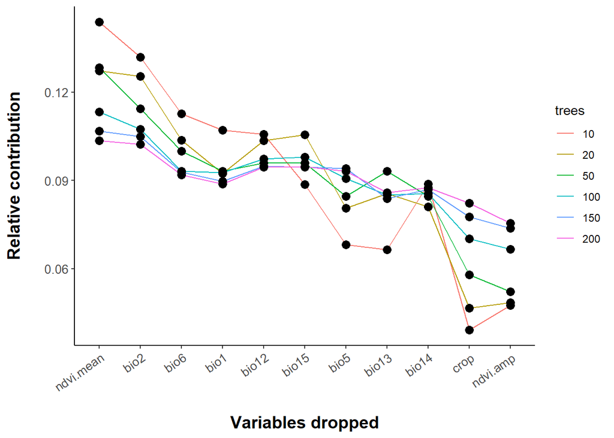

```
#> [1] Number of variables included: 11
#> [1] Dropped:
#> [1]
#> [1] ---------------------------------------
#> [1] Number of variables included: 10
#> [1] Dropped:
#> [1] ndvi.amp
#> [1] ---------------------------------------
#> [1] Number of variables included: 9
#> [1] Dropped:
#> [1] ndvi.amp crop
#> [1] ---------------------------------------
#> [1] Number of variables included: 8
#> [1] Dropped:
#> [1] ndvi.amp crop     bio5
```

[output cut: 21 more lines]

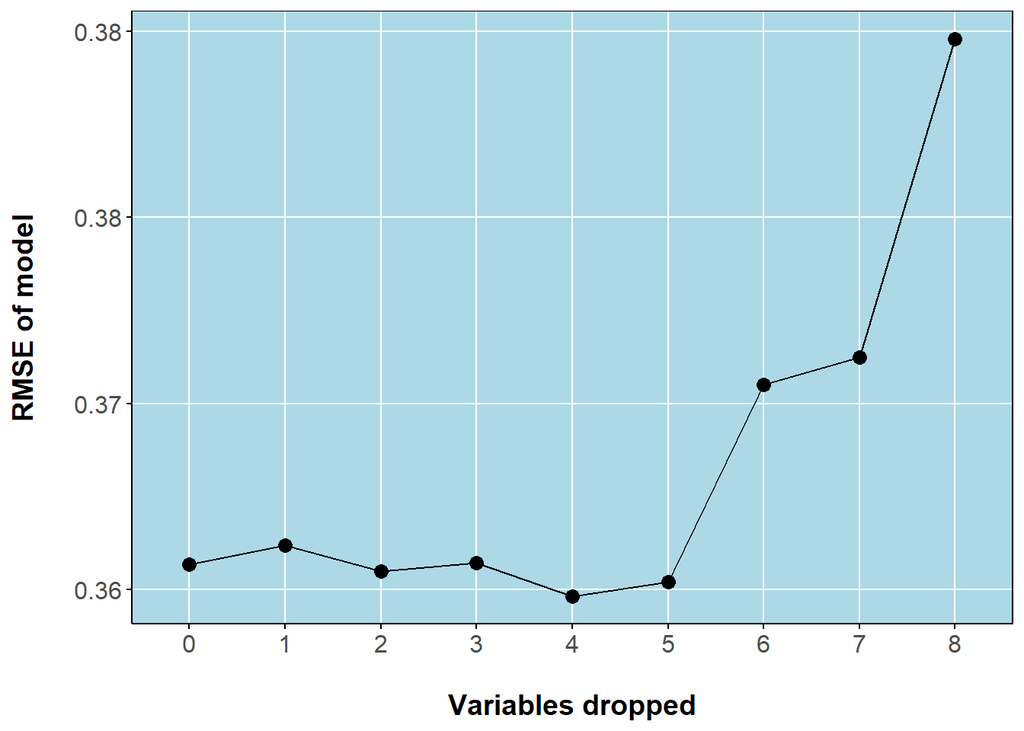

```
#> [1] ---------------------------------------
#> [1] Final recommended variable list
#> [1] bio1      bio12     bio13     bio15     bio2      bio6      ndvi.mean
#>
#> Running BART with binary y
#>
#> number of trees: 200
#> number of chains: 1, number of threads 1
#> Prior:
#>  k: 2.000000
#>  power and base for tree prior: 2.000000 0.950000
#>  use quantiles for rule cut points: false
#> data:
#>  number of training observations: 3478
#>  number of test observations: 0
#>  number of explanatory variables: 7
#>
#> Cutoff rules c in x<=c vs x>c
#> Number of cutoffs: (var: number of possible c):
#> (1: 100) (2: 100) (3: 100) (4: 100) (5: 100)
#> (6: 100) (7: 100)
#>
#> offsets:
#>  reg : 0.00 0.00 0.00 0.00 0.00
#> Running mcmc loop:
#> iteration: 100 (of 1000)
#> iteration: 200 (of 1000)
#> iteration: 300 (of 1000)
#> iteration: 400 (of 1000)
#> iteration: 500 (of 1000)
#> iteration: 600 (of 1000)
#> iteration: 700 (of 1000)
#> iteration: 800 (of 1000)
#> iteration: 900 (of 1000)
#> iteration: 1000 (of 1000)
#> total seconds in loop: 7.982328
#>
#> Tree sizes, last iteration:
#> [1] 2 3 2 3 4 3 2 2 3 1 3 2 4 3 1 3 3 2
#> 3 2 2 2 3 2 3 2 2 3 2 2 2 5 4 2 4 2 3 3
#> 3 2 2 5 4 2 2 2 2 2 2 3 2 2 2 3 2 4 6 2
#> 1 1 1 3 2 2 2 2 2 2 2 2 2 2 2 3 2 2 2 2
#> 2 2 3 2 2 1 3 2 2 1 2 3 2 3 2 2 3 3 3 2
#> 2 3 2 2 3 2 2 2 3 2 2 2 3 2 1 2 3 2 3 3
#> 4 2 2 2 4 2 2 3 3 3 2 3 3 5 2 3 3 3 2 3
#> 2 3 4 2 2 2 3 1 3 2 3 2 2 3 3 3 2 2 2 2
#> 2 2 2 2 2 2 2 2 2 2 3 2 2 3 2 2 2 2 2 2
#> 2 2 2 3 1 3 2 2 2 3 4 4 3 2 2 3 2 3 3 3
#> 3 3
#>
#> Variable Usage, last iteration (var:count):
#> (1: 32) (2: 41) (3: 41) (4: 42) (5: 41)
#> (6: 43) (7: 46)
#> DONE BART
```

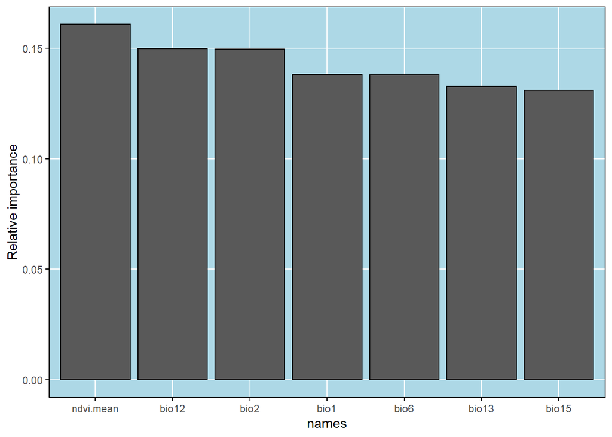

```
#> Call:  bart xdata[, vs] ydata TRUE
#>
#> Predictor list:
#>  bio1 bio12 bio13 bio15 bio2 bio6 ndvi.mean
#>
#> Area under the receiver-operator curve
#> AUC = 0.91
#>
#> Recommended threshold (maximizes true skill statistic)
#> Cutoff =  0.46
#> TSS =  0.65
#> Resulting type I error rate:  0.11
#> Resulting type II error rate:  0.24
```

```r
sdm <- bart.step(xdata = all.cov[,xvars],
                 ydata = all.cov[,'tick'],
                 full = TRUE,
                 iter.plot=5,
                 iter.step=10,
                 quiet = TRUE)
```

Out of all the variables, “crop” seems to be especially undesirable as a predictor. A few other variables seem like they might not be helping the model either, but we probably need a systematic way to deal with that.